# ps2_Siyuan_Wu

## Project set 2

Siyuan Wu

github: https://github.com/KeldonWu/stats-506

### Problem 1 Dice Game

#### a

Version 1

```r
play_dice_v1<-function(x){

  t=0
  for (i in 1:x){
    t=t-2#delete the cost each time
    u=sample(1:6,1)#sample each dice
    if(u==3|u==5){
      t=t+2*u
    }}
  return(t)
}
```

```r
play_dice_v1(10)
```

```
[1] 10
```

```r
play_dice_v1(10)
```

```
[1] 16
```

Version 2

```r
play_dice_v2<-function(x){
  result_of_dice=sample(1:6,x,replace = TRUE)
  t=ifelse(result_of_dice==3|result_of_dice==5,result_of_dice*2-2,-2)
  #vectorized on list, learned from https://stackoverflow.com/questions/9449184/if-else-vs-ifelse-with-lists
  return(sum(t))
}
```

```r
play_dice_v2(10)
```

```
[1] 28
```

```r
play_dice_v2(10)
```

```
[1] 6
```

Version 3

```r
play_dice_v3<-function(x){
  result_of_dice=sample(1:6,x,replace = TRUE)
  t=table(result_of_dice)
  res=-2*x
  if(!is.na(as.numeric(t[names(t)==5][1]))){
  res=res+as.numeric(t[names(t)==5][1])*2*5}#check there has result with 5
  if(!is.na(as.numeric(t[names(t)==3][1]))){
  res=res+as.numeric(t[names(t)==3][1])*2*3}#check there has result with 3
  return (res)
}
```

```r
play_dice_v3(1)
```

```
[1] -2
```

Version 4

```r
play_dice_v4<-function(x){
  result_of_dice=sample(1:6,x,replace = TRUE)
t=sapply(result_of_dice,function(a){if(a==3|a==5) a*2-2 else -2})# use a new list to represent the result of calculation
return(sum(t))
}
```

```r
play_dice_v4(5)
```

```
[1] -10
```

#### b

```r
play_dice_v1(3)
```

```
[1] 4
```

```r
play_dice_v1(3000)
```

```
[1] 2174
```

```r
play_dice_v2(3)
```

```
[1] -6
```

```r
play_dice_v2(3000)
```

```
[1] 2356
```

```r
play_dice_v3(3)
```

```
[1] -6
```

```r
play_dice_v3(3000)
```

```
[1] 2122
```

```r
play_dice_v4(3)
```

```
[1] 14
```

```r
play_dice_v4(3000)
```

```
[1] 2076
```

#### c

We use set.seed() function to control randomness. In this part, we need to use this function everytime before simulation.

```r
#use the same list every time
print("Result of version 1:")
```

```
[1] "Result of version 1:"
```

```r
set.seed(42)
print(play_dice_v1(3))
```

```
[1] 4
```

```r
print(play_dice_v1(3000))
```

```
[1] 1978
```

```r
set.seed(42)
print("Result of version 2:")
```

```
[1] "Result of version 2:"
```

```r
print(play_dice_v2(3))
```

```
[1] 4
```

```r
print(play_dice_v2(3000))
```

```
[1] 1978
```

```r
set.seed(42)
print("Result of version 3:")
```

```
[1] "Result of version 3:"
```

```r
print(play_dice_v3(3))
```

```
[1] 4
```

```r
print(play_dice_v3(3000))
```

```
[1] 1978
```

```r
set.seed(42)
print("Result of version 4:")
```

```
[1] "Result of version 4:"
```

```r
print(play_dice_v4(3))
```

```
[1] 4
```

```r
print(play_dice_v4(3000))
```

```
[1] 1978
```

We can see that they have the same result.

#### d

```r
library(microbenchmark)
```

```r
timecheck<-function(tries){
return(microbenchmark(
  play_dice_v1(tries),
  play_dice_v2(tries),
  play_dice_v3(tries),
  play_dice_v4(tries),times=20#set times to be lower because my r break down due to long runtime
))
}
```

```r
set.seed(10)
timecheck(1000)
```

```
Unit: microseconds
                expr      min        lq       mean    median        uq      max
 play_dice_v1(tries) 2248.973 2281.5680 2529.23055 2321.9325 2390.8125 4536.240
 play_dice_v2(tries)   41.082   43.5215   46.48375   45.2025   48.2570   60.639
 play_dice_v3(tries)   78.146   80.1755   88.09670   83.1070   87.6785  131.610
 play_dice_v4(tries)  273.060  276.0120  282.30550  279.7635  284.0070  309.099
 neval cld
    20  a
    20   b
    20   b
    20   b
```

```r
timecheck(100000)
```

```
Unit: milliseconds
                expr        min         lq       mean     median         uq
 play_dice_v1(tries) 244.044382 253.742789 263.129978 258.870166 264.778554
 play_dice_v2(tries)   3.484713   3.586762   3.797976   3.647380   3.711074
 play_dice_v3(tries)   3.725916   3.967570   4.211912   4.027615   4.096392
 play_dice_v4(tries)  30.757585  32.376142  37.414406  34.056670  36.371080
        max neval cld
 320.965179    20 a
   6.731626    20  b
   7.844735    20  b
  78.697163    20   c
```

We can see that the version 2 has the shortest running time, while version 1 has the longest running time in both cases. Version 4 has the second longest running time while version 3 has the third longest running time. The rank is same in both cases.

#### e

```r
montecarl<-function(num_sims,tries){#we separate numbers of simulation and tries here
  res=0
  for (i in 1:num_sims){
    res=res+play_dice_v2(tries)#we choose the function with the smallest running time
  }
  return(res/num_sims/tries)#get the simulated expectation of throwing one dice
}
```

```r
montecarl(100000,100)
```

```
[1] 0.66788
```

```r
montecarl(100000,1)
```

```
[1] 0.67272
```

As shown in the simulation,It is not a fair game for both sides, the challenger has an advantage in expectation. Also, we can show it in calculation that:

$$\begin{aligned}
E(x)=&P(x\neq3 \cap x\neq5)\cdot(-2)+P(x=3)\cdot(3\cdot2-2)+P(x=5)\cdot(5\cdot2-2)\\
=&-\frac{2\cdot2}{3}+\frac{4}{6}+\frac{8}{6}=\frac{2}{3}>0
\end{aligned}$$

### Problem 2 Linear Regression

#### a

```r
library(multcomp)
cars <- read.csv("cars.csv")
```

```r
colnames(cars)<-c("height",
                  "length",
                  "width",
                  "driveline",
                  "engine_type",
                  "engine_hybrid",
                  "forward_gears",
                  "transmission",
                  "city_mpg",
                  "fuel_type",
                  "highway_mpg",
                  "classification",
                  "id",
                  "make",
                  "model_year",
                  "year",
                  "horsepower",
                  "torque")
```

#### b

```r
carsgasoline<-cars[which(cars$fuel_type=="Gasoline"),]
```

#### c

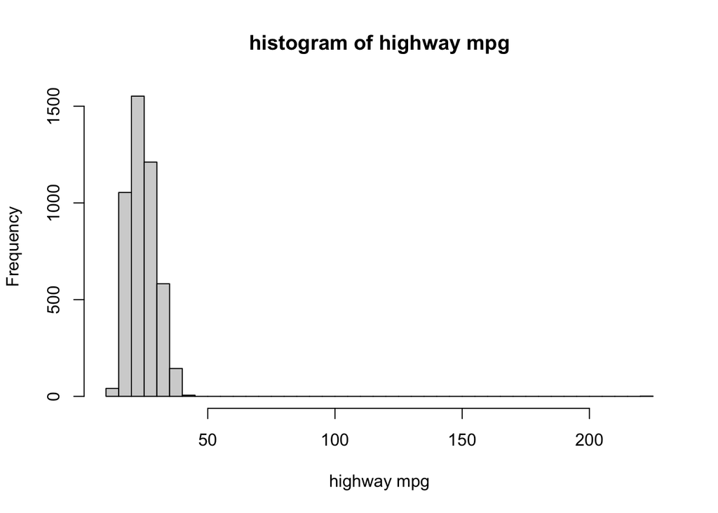

```r
hist(carsgasoline$highway_mpg,breaks=30,main = "histogram of highway mpg",xlab = "highway mpg")
```

We can observe that the data have potential outlier over 50. We delete these values over 50 in our dataset.

```r
head(carsgasoline[order(carsgasoline$highway_mpg,decreasing=TRUE),]$highway_mpg)#retrive the five largest highway mpg
```

```
[1] 223  42  42  42  41  41
```

We just delete the only one that is larger than 50.

```r
carsgasoline=carsgasoline[which(carsgasoline$highway_mpg<50),]
```

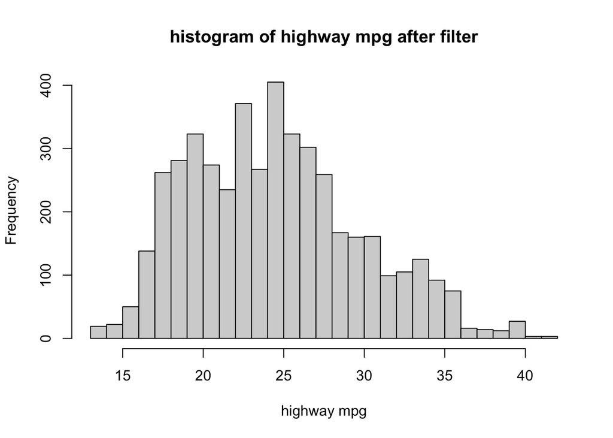

```r
hist(carsgasoline$highway_mpg,breaks=30,main = "histogram of highway mpg after filter",xlab = "highway mpg")
```

#### d

```r
carsgasoline$year=as.factor(carsgasoline$year)# change to be factor variable
lm1<-lm(highway_mpg~torque+width+length+height+horsepower+year,carsgasoline)
summary(lm1,digits=5)
```

```
Call:
lm(formula = highway_mpg ~ torque + width + length + height +
    horsepower + year, data = carsgasoline)

Residuals:
     Min       1Q   Median       3Q      Max
-10.9695  -2.4981  -0.3671   2.4164  19.8079

Coefficients:
              Estimate Std. Error t value Pr(>|t|)
(Intercept) 32.4107371  0.5486291  59.076   <2e-16 ***
torque      -0.0517480  0.0016727 -30.937   <2e-16 ***
width       -0.0008147  0.0006867  -1.186   0.2356
length       0.0011433  0.0006710   1.704   0.0885 .
height       0.0104613  0.0008555  12.228   <2e-16 ***
horsepower   0.0171254  0.0017290   9.905   <2e-16 ***
year2010    -0.4497677  0.5138721  -0.875   0.3815
year2011     0.0709912  0.5130245   0.138   0.8899
year2012     1.2925749  0.5170481   2.500   0.0125 *
---
Signif. codes:  0 '***' 0.001 '**' 0.01 '*' 0.05 '.' 0.1 ' ' 1

Residual standard error: 3.494 on 4581 degrees of freedom
Multiple R-squared:  0.5626,    Adjusted R-squared:  0.5618
F-statistic: 736.5 on 8 and 4581 DF,  p-value: < 2.2e-16
```

#### e

```r
lm2<-lm(highway_mpg~torque+width+length+height+horsepower+year+horsepower:torque,carsgasoline)#add interaction in this model
summary(lm2)
```

```
Call:
lm(formula = highway_mpg ~ torque + width + length + height +
    horsepower + year + horsepower:torque, data = carsgasoline)

Residuals:
     Min       1Q   Median       3Q      Max
-11.2605  -2.2128  -0.2145   2.0901  21.6514

Coefficients:
                    Estimate Std. Error t value Pr(>|t|)
(Intercept)        4.247e+01  5.706e-01  74.436  < 2e-16 ***
torque            -8.766e-02  1.823e-03 -48.090  < 2e-16 ***
width             -1.666e-03  6.131e-04  -2.717  0.00661 **
length             1.189e-03  5.985e-04   1.987  0.04700 *
height             7.061e-03  7.696e-04   9.175  < 2e-16 ***
horsepower        -1.644e-02  1.827e-03  -9.000  < 2e-16 ***
year2010          -5.604e-01  4.584e-01  -1.222  0.22162
year2011          -2.967e-02  4.577e-01  -0.065  0.94832
year2012           1.185e+00  4.613e-01   2.569  0.01024 *
torque:horsepower  1.142e-04  3.330e-06  34.301  < 2e-16 ***
---
Signif. codes:  0 '***' 0.001 '**' 0.01 '*' 0.05 '.' 0.1 ' ' 1

Residual standard error: 3.117 on 4580 degrees of freedom
Multiple R-squared:  0.652, Adjusted R-squared:  0.6513
F-statistic: 953.3 on 9 and 4580 DF,  p-value: < 2.2e-16
```

```r
library(interactions)
```

```r
summary(carsgasoline$horsepower)
```

```
   Min. 1st Qu.  Median    Mean 3rd Qu.    Max.
  100.0   185.0   263.0   267.5   317.0   638.0
```

We choose value as 150, 250, 350 here.

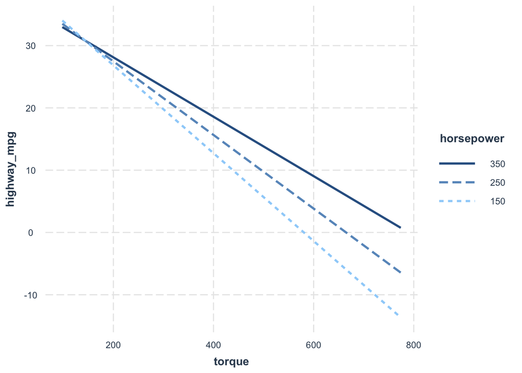

```r
interact_plot(lm2,pred="torque",modx="horsepower",modx.values=c(150,250,350),at=list(year="2011"),data=carsgasoline)
```

Choosing year in 2011, we can see that with a larger horsepower the slope of line is expected to be bigger, showing that there is interaction between these two variables.

#### f

```r
carsgasoline$year2010=ifelse(carsgasoline$year==2010,1,0)
carsgasoline$year2011=ifelse(carsgasoline$year==2011,1,0)
carsgasoline$year2012=ifelse(carsgasoline$year==2012,1,0)
X<-as.matrix(cbind(rep(1,length(carsgasoline$torque)),
                   carsgasoline$torque,
                   carsgasoline$width,
                   carsgasoline$length,
                   carsgasoline$height,
                   carsgasoline$horsepower,
                   carsgasoline$year2010,
                   carsgasoline$year2011,
                   carsgasoline$year2012))#set up the X matrix add the intercept value to be 1 at the first column
y<-as.matrix(carsgasoline$highway_mpg)
beta<-solve((t(X)%*%X))%*%t(X)%*%y
```

```r
beta=data.frame(t(beta))
colnames(beta)=c("(Intercept)",
                 "torque",
                 "width",
                 "length",
                 "height",
                 "horsepower",
                 "year2010",
                 "year2011",
                 "year2012")
print(beta)
```

```
  (Intercept)      torque         width    length     height horsepower
1    32.41074 -0.05174801 -0.0008146917 0.0011433 0.01046135  0.0171254
    year2010   year2011 year2012
1 -0.4497677 0.07099119 1.292575
```

```r
print(lm1$coefficients)
```

```
  (Intercept)        torque         width        length        height
32.4107371447 -0.0517480111 -0.0008146917  0.0011433004  0.0104613453
   horsepower      year2010      year2011      year2012
 0.0171253987 -0.4497677480  0.0709911939  1.2925748832
```

We can see that they have the same value.